# Introducción a gráficos en ggplot2

Víctor Macías E.

Aún cuando usaremos varios paquetes para la construcción de gráficos, el principal será `ggplot2`. Estas notas están basadas en el siguiente texto:

Wickham, H. 2019. ggplot2: elegant graphics for data analysis.  
https://ggplot2-book.org/

# ¿Cómo construir un gráfico en `ggplot2`?

`ggplot(data = <DATOS>) + <GEOM_FUNCTION>(mapping = aes(<MAPPINGS>))`

# Aesthetic

Un `aesthetic` es una propiedad visual de los objetos en el gráfico como, por ejemplo, tamaño (`size`), forma (`shape`) y color (`colour`). Si se quiere asociar una de estas propiedades visuales al nombre de una variable, se debe realizar al interior de `aes()`.

Por ejemplo, `shape` permite el uso de distintas formas para representar una o varias variables como:

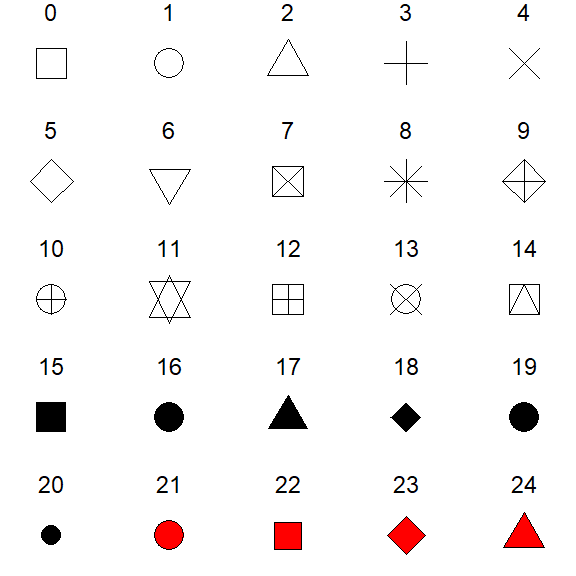

# Geoms

Un *geom* es el objeto geométrico que un gráfico usa para representar los datos. En muchos casos, *geom* define el tipo de gráfico; en otros, se pueden combinar varios para construir un gráfico.

`ggplot2` provides over 40 *geoms*. A continuación se presentan los más usados:

| geom | Descripción |
| --- | --- |
| geom_point | gráfico de dispersión |
| geom_bar | gráfico de barras |
| geom_col | gráfico de barras |
| geom_line | gráfico de líneas |
| geom_boxplot | diagrama de caja |
| geom_histogram | histograma |
| geom_hline | línea de referencia horizontal |
| geom_vline | línea de referencia vertical |
| geom_abline | línea de referencia |
| geom_rect | rectángulo |
| geom_segment | segmento de línea |

Además, existen una serie de paquetes que extienden `ggplot2`, algunos de los cuales pueden encontrarse en:

https://exts.ggplot2.tidyverse.org/gallery/

Por ejemplo, el paquete `calendR` permite crear calendarios personalidados:

[figure not shown]

```r
library(calendR)
calendR(mbg.col = 4,
        months.col = "white",
        col = "#ffffff",
        weeknames = c("L", "M", "M",
                      "J", "V", "S", "D"),
        day.size = 2.5)
```

# ¿geom_bar() o geom_col()?

- `geom_bar()` hace que la altura de la barra sea proporcional al número de casos en cada grupo (o si se incluyen *weights*, la altura es proporcional a la suma de éstos). Usa `stat_count()` por defecto, es decir, cuenta el número de casos en cada posición en el eje X.
- `geom_col()` hace que la altura de la barra sea igual a los valores en los datos. Usa `stat_identity()`, representando los datos tal cual se presentan en la base de datos.

# Transformaciones estadísticas

Un gráfico de barras generados con `geom_bar()` muestra el número de casos en cada grupo o categoría de una variable. El algoritmo usado para calcular los valores es llamado *stat*

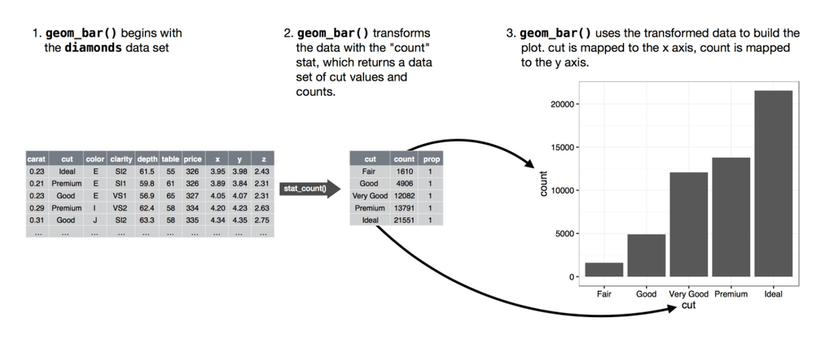

# Facets

La separación de gráficos de acuerdo a distintos valores de una variable puede realizarse para una sola variable usando `facet_wrap` o una combinación de dos variables a través de `facet_grid`. Se recomienda también revisar `grid.arrange` del paquete `gridExtra`.

# Etiquetas

Para añadir etiquetas puede usarse `labs()` al interior del cual pueden agregarse:

- `title`
- `subtitle`
- `caption`
- `x`
- `y`

Además, pueden incluirse expresiones matemáticas en lugar de texto, reemplazando "" por `quote()`. Se recomienda revisar opciones en `?plotmath`

# Anotaciones

Si se quiere etiquetar una observación o un grupo de éstas, se puede usar `geom_text()`, `geom_label()` y `annotate()`. Se recomienda revisar: https://ggplot2.tidyverse.org/reference/geom_text.html y https://ggplot2.tidyverse.org/reference/annotate.html

# Escalas

Las escalas controlan cómo los datos son representados en el gráfico como, por ejemplo, colores, breaks en el eje X o Y, leyendas, etc.

Entre las escalas de colores más utilizadas son las de ColorBrewer que está documentada en http://colorbrewer2.org/ y se encuentra disponible en el paquete `RColorBrewer`. A continuación se presentan 3 tipos de escalas de colores: secuencial, cualitativa y divergente.

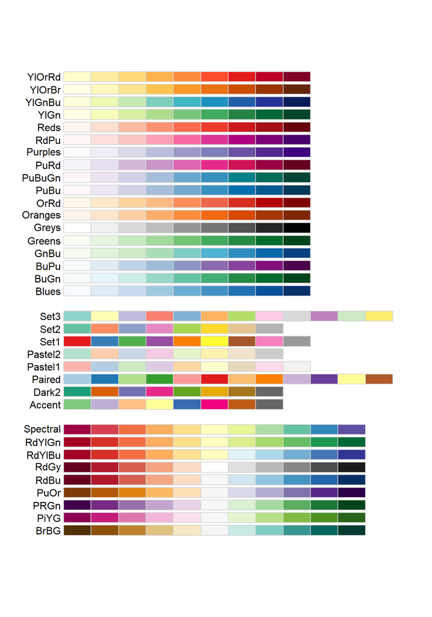

# themes

Pemiten personalizar las partes de un gráfico no relacionadas a datos. `ggplot2` incluye los siguientes 8 *themes*:

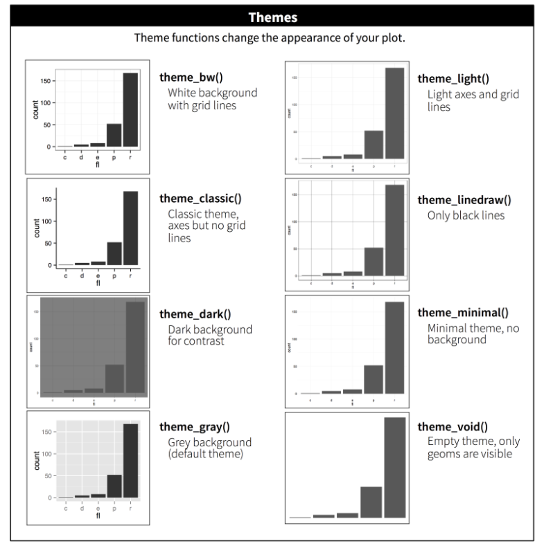

Además, el paquete `ggthemes` contiene una lista de *themes* adicionales, los cuales pueden revisarse en https://cran.r-project.org/web/packages/ggthemes/ggthemes.pdf

Por otra parte, se puede acceder a una mayor personalización de un gráfico especificando en *theme* los elementos de un gráfico que se desean modificar. Por ejemplo, para cambiar la posición de `legend` usar `theme(legend.position = )`. Por defecto, la ubicación de la leyenda será a la derecha del gráfico.

Los componentes necesarios para llevar a cabo la personalización de un gráfico incluyen:

- Elementos

Especifican los elementos no relacionados a datos que se pueden controlar. Por ejemplo, `plot.title` controla la apariencia del título del gráfico, `axis.ticks.x` controla los ticks (marcadores) en el eje X.

- Funciones

Cada elemento está asociado con una función específica. Por ejemplo, `element_text()` puede controlar el tamaño de la fuente, color y si se usa o no itálica o negrita en elementos como `plot.title`. Hay cuatro tipos de `element_text()`, `element_line()`, `element_rect()` y `element_blank()`. La especificación de elementos y funciones al interior de `theme` se realiza de la siguiente forma:

`theme(element.name = element_function())`

Para una más completa revisión de las opciones disponibles, se recomienda revisar: https://ggplot2.tidyverse.org/reference/theme.html

# Tamaño de una figura

Para controlar el tamaño de una figura existen cinco opciones: `fig.width`, `fig.height`, `fig.asp`, `out.width` y `out.height`.

# ¿Cómo guardar un gráfico?

Se puede usar `ggsave`. Se recomienda revisar: https://ggplot2.tidyverse.org/reference/ggsave.html